# Traffic sign recognition using pytorch CNN

## Reference:

1. Project idea from - Project Pro https://www.projectpro.io/article/neural-network-projects/440
2. Dataset - Kaggle https://www.kaggle.com/datasets/meowmeowmeowmeowmeow/gtsrb-german-traffic-sign
3. Model architecture - Inspired by VGG architecture learned from CSE 475(Foundation of Machine Learning) and DAT 492 (Deep learning structures) courses
4. Usage of gen AI for Plotting images and classes(testing vs training image plot), learned to prepare dataset from pandas dataframe to a version that Dataloader can use better (with dynamic transforms)

## Abstract

Welcome to my final project report for DAT 494 Deep learning class.

In this project, I have implemented a multiclass CNN classifier model that can classify different traffic signs on the road, a fundamental task in broader context of autonomous driving. I selected this topic because I want to explore about how self driving cars perceive and recognize objects in real time. Through this project, I have experimented on data manupulations techniques using pandas, implementing CNNs models, achieving best accuracy by following different optimization techniques. I am able to get **99.46% accuracy on validation set**. I saved the best performing model (minimum validation loss), and got **96.38% accuracy on test set**.

## Introduction

Autonomous driving has emerged as one of the most transformative applications of machine learning and AI. There are many integrated components that work together to make safe driving possible such as real time object detection, sensors getting real time data about its surrounding environments and fast decision making. In this project, I have focused on developing a model that can classify traffic signs (one of the components of self driving cars). I am planning to continue developing on this project during summer to experiment more functionalities related to self driving.

## Methods

1. Getting dataset from kaggle
2. Data preprocessing and checking how the input looks like
3. Model architecture definition
4. Training loop
5. Plotting train vs validation loss and accuracy as results
6. Testing the best performing model on test data
7. Model output (image, prediction, true label) and analysis

Detailed explanation will be given along the code below

starting with importing necessary libraries.

```python
## importing necessary libraries
import pandas as pd
import numpy as np
import matplotlib.pyplot as plt
import os
import zipfile
import sklearn.model_selection
from sklearn.model_selection import train_test_split
from PIL import Image

import torch
import torch.nn as nn
import torch.nn.functional as F
import torch.optim as optim
from torch.utils.data import DataLoader, random_split, Dataset

import torchvision
import torchvision.transforms as transforms
```

```python
# check if GPU is available (I ran in Colab for faster training)
if torch.cuda.is_available():
  print("GPU is available and enabled!")
  print("Device:", torch.cuda.get_device_name(0))
else:
  print("GPU is not available or enabled.")
```

```
GPU is available and enabled!
Device: Tesla T4
```

## 1. Getting dataset from Kaggle

I am installing kaggle here, getting kaggle public API so that I can download the traffic signs dataset. I used Google colab and hence the directory are all set up according to colab.

```python
!pip install -q kaggle
```

```python
# uploaded kaggle apikey
from google.colab import files
files.upload()
```

```python
!mkdir -p ~/.kaggle
!cp kaggle.json ~/.kaggle/
!chmod 600 ~/.kaggle/kaggle.json
```

```python
# Downloading the dataset from kaggle
!kaggle datasets download -d meowmeowmeowmeowmeow/gtsrb-german-traffic-sign
```

```
Dataset URL: https://www.kaggle.com/datasets/meowmeowmeowmeowmeow/gtsrb-german-traffic-sign
License(s): CC0-1.0
```

```python
## The dataset is in zipped format. Let's unzip the file
if not os.path.exists('/content/gtsrb-german-traffic-sign'):
  with zipfile.ZipFile('/content/gtsrb-german-traffic-sign.zip', 'r') as zip_ref:
      zip_ref.extractall('/content/gtsrb-german-traffic-sign')
  print("Dataset extracted to /content/gtsrb-german-traffic-sign")
else:
  print("Dataset already extracted")
```

```
Dataset extracted to /content/gtsrb-german-traffic-sign
```

## 2. Data preprocessing

Using pandas library, I read the csv files of training set, test set, and meta.csv and explore what columns are there in each set to undersand the dataset better. There are 43 different classes (43 unique traffic signs) to classify. I have printed the first few rows of train and meta dataframes below, along with the columns they have.

```python
#using pandas to read csv files and store it as dataframe
train_df = pd.read_csv('/content/gtsrb-german-traffic-sign/Train.csv')
test_df = pd.read_csv('/content/gtsrb-german-traffic-sign/Test.csv')
meta_df = pd.read_csv('/content/gtsrb-german-traffic-sign/Meta.csv')

print(train_df.head())
print(meta_df.head())

# Printing the number of classes (43)
num_classes = len(train_df['ClassId'].unique())
print(f"\nNumber of classes: {num_classes}")
```

```
   Width  Height  Roi.X1  Roi.Y1  Roi.X2  Roi.Y2  ClassId  \
0     27      26       5       5      22      20       20
1     28      27       5       6      23      22       20
2     29      26       6       5      24      21       20
3     28      27       5       6      23      22       20
4     28      26       5       5      23      21       20

                             Path
0  Train/20/00020_00000_00000.png
1  Train/20/00020_00000_00001.png
2  Train/20/00020_00000_00002.png
3  Train/20/00020_00000_00003.png
4  Train/20/00020_00000_00004.png
          Path  ClassId  ShapeId  ColorId SignId
0  Meta/27.png       27        0        0   1.32
1   Meta/0.png        0        1        0   3.29
2   Meta/1.png        1        1        0   3.29
3  Meta/10.png       10        1        0   3.27
4  Meta/11.png       11        0        0   1.22

Number of classes: 43
```

[figure not shown]

```python
'''
Checking input images (from train set).
Printing input images and the classId to check what kind of images are present in the training dataset.
The images of traffic signs have been taken during different time periods.
'''

explore_df = train_df.sample(n=25, random_state=42)

fig, axes = plt.subplots(5,5, figsize=(10,10))
for i, (index, row) in enumerate(explore_df.iterrows()):
  image_path = '/content/gtsrb-german-traffic-sign/' + row['Path']
  img = plt.imread(image_path)
  axes[i//5, i%5].imshow(img)
  axes[i//5, i%5].set_title(f"Class: {row['ClassId']}")
  axes[i//5, i%5].axis('off')

plt.tight_layout()
plt.show()
```

```python
'''
1. Splitting the dataset to train data, validation data, using sklearn.train_test_split()
2. printing the shape of training and validation set after splitting. Followed a 80-20 split between training and validation.
3. train data shape -> 31367 rows (data samples), 8 columns
4. validation data shape -> 7842 rows (data samples), 8 columns
'''
# stratify - fair distribution of images to train and validation set based on class Id. class imbalance handling
train_data, val_data = train_test_split(train_df, test_size=0.2, stratify=train_df['ClassId'],random_state=42)
print(f"Train data shape: {train_data.shape}")
print(f"Validation data shape: {val_data.shape}")
```

```
Train data shape: (31367, 8)
Validation data shape: (7842, 8)
```

```python
'''
Custom dataset loader to get images, and corresponding ClassId(labels).
returns image(as tensor after transforms), label, which will be used by DataLoader
'''
class TrafficSignDataset(Dataset):
  # stores dataframe, root directory, transforms (pass diffent data and transforms- train, test)
  def __init__(self, dataframe, image_dir, transforms=None):
    self.dataframe = dataframe.reset_index(drop=True)
    self.image_dir = image_dir
    self.transforms = transforms

  # get length of the dataframe -> required by DataLoader (iteration)
  def __len__(self):
    return len(self.dataframe)

  # get images from folder and classId. if transforms given, apply transforms (data augmentation for train_transforms)
  def __getitem__(self, index):
    image_path = os.path.join(self.image_dir, self.dataframe.loc[index, 'Path'])
    image = Image.open(image_path)
    label = self.dataframe.loc[index, 'ClassId']

    if self.transforms:
      image = self.transforms(image)

    return image, label
```

## Transforms and data loaders

Here, I define two transforms: one for train dataset and another for validation and test datasets.

First, I resize the images to dim=32x32 The train_transform will have data augmentation: RandomHorizontalFlip(), RandomRotation(), ColorJitter(). This helps the model to give a generalized performance and hence, helps in predicting unseen data. Added Normalization with mean and standard deviation values used by ImageNet for RGB.

```python
# Defining transforms with data augmentation, and defining train loader, validation loader, test loader

train_transform = transforms.Compose([
    # Resizing images to 32x32 for easier computation and uniform size for cnn layers
    transforms.Resize((32, 32)),

    # Randomly do horizontal flip, with probability default- 0.5 (50%)
    transforms.RandomHorizontalFlip(),

    # rotate 15 degress on random image
    transforms.RandomRotation(15),

    # change brightness, saturation, contrast, hue of image
    transforms.ColorJitter(brightness=0.2, contrast=0.2, saturation=0.2, hue=0.1),
    transforms.ToTensor(),

    # Referred to imageNet mean and standard deviation for RGB
    transforms.Normalize((0.485, 0.456, 0.406), (0.229, 0.224, 0.225))
])

# Defining a separate transform for validation and test datasets (here, data augmentation for generalization is not necessary)

val_test_transform = transforms.Compose([
    transforms.Resize((32, 32)),
    transforms.ToTensor(),
    transforms.Normalize((0.485, 0.456, 0.406), (0.229, 0.224, 0.225))
])

# Creating 3 datasets; giving dataframe, path to files(colab directory), transform to TrafficSignDataset class
train_dataset = TrafficSignDataset(train_data, '/content/gtsrb-german-traffic-sign/', transforms=train_transform)
val_dataset = TrafficSignDataset(val_data, '/content/gtsrb-german-traffic-sign/', transforms=val_test_transform)
test_dataset = TrafficSignDataset(test_df, '/content/gtsrb-german-traffic-sign/', transforms=val_test_transform)

# Dataloaders: wraps iterable around the dataset to enable easy access to the samples (Pytorch documentation)
train_loader = DataLoader(train_dataset, batch_size=32, shuffle=True) # randomize order
val_loader = DataLoader(val_dataset, batch_size=32, shuffle=False)
test_loader = DataLoader(test_dataset, batch_size=32, shuffle=False)

'''
checking shape of train_loader
Images shape: torch.Size([32, 3, 32, 32]) batchsize=32, 3 channels(RGB), 32x32
labels shape: torch.Size([32]) batchsize=32
'''
images, labels = next(iter(train_loader))
print(f"images shape: {images.shape}")
print(f"labels shape: {labels.shape}")
```

```
images shape: torch.Size([32, 3, 32, 32])
labels shape: torch.Size([32])
```

[output not shown]

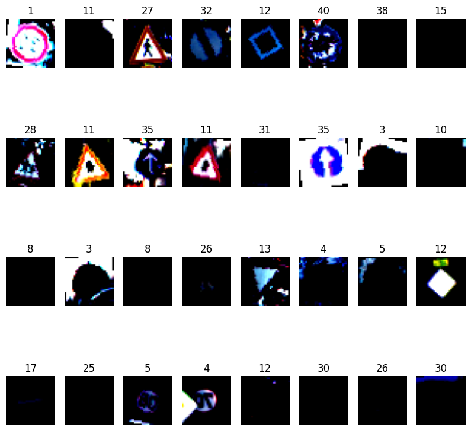

```python
'''
Checking images in one(next) batch of train loader after data augmentation
We see images with varying brightness, and different angles that shows that the images are normalized using transforms
'''

fig1, ax1 = plt.subplots(4, 8, figsize=(10, 10))
ax1 = ax1.flatten()

for i in range(32):
    ax1[i].imshow(images[i].permute(1, 2, 0).numpy())
    ax1[i].set_title(labels[i].item())
    ax1[i].set_axis_off()
```

## Model Architecture

Inspired from VGG architecture, I have implemented a simpler version: 3 blocks of conv2d layers with 2 convolution layers in one block. 1 fully connected layer, and 1 output layer that has 43 neurons (for 43 classes).

Included BatchNormalization after each convolution layer to prevent overfitting, improves regularization, and faster convergence. Dropout added between two blocks to prevent overfitting.

```python
# Model definition Following VGG architecture: 2x conv layer followed by maxPool between the blocks. Simple VGG, that can extract necessary features.
# BatchNormalization after each conv2d layer - for early convergence, faster and stable learning.
# Dropout - randomly sets fraction of units to zeros (eg. 25% of activation are set to zero) - regularization technique
class TrafficSignModel(nn.Module):
    def __init__(self):
        super(TrafficSignModel, self).__init__()

        # block 1
        self.conv1_1 = nn.Conv2d(3, 32, kernel_size=3, stride=1, padding='same')
        self.bn1_1 = nn.BatchNorm2d(32)
        self.conv1_2 = nn.Conv2d(32, 32, kernel_size=3, stride=1, padding='same')
        self.bn1_2 = nn.BatchNorm2d(32)
        self.pool1 = nn.MaxPool2d(kernel_size=2, stride=2)
        self.dropout1 = nn.Dropout(0.25)

        # block 2
        self.conv2_1 = nn.Conv2d(32, 64, kernel_size=3, stride=1, padding='same')
        self.bn2_1 = nn.BatchNorm2d(64)
        self.conv2_2 = nn.Conv2d(64, 64, kernel_size=3, stride=1, padding='same')
        self.bn2_2 = nn.BatchNorm2d(64)
        self.pool2 = nn.MaxPool2d(kernel_size=2, stride=2)
        self.dropout2 = nn.Dropout(0.25)

        # block 3
        self.conv3_1 = nn.Conv2d(64, 128, kernel_size=3, stride=1, padding='same')
        self.bn3_1 = nn.BatchNorm2d(128)
        self.conv3_2 = nn.Conv2d(128, 128, kernel_size=3, stride=1, padding='same')
        self.bn3_2 = nn.BatchNorm2d(128)
        self.pool3 = nn.MaxPool2d(kernel_size=2, stride=2)
        self.dropout3 = nn.Dropout(0.25)

        self.flatten = nn.Flatten()

        # fully connected layer and output layer
        self.fc1 = nn.Linear(128 * 4 * 4, 512)
        self.bn4 = nn.BatchNorm1d(512)
        self.dropout4 = nn.Dropout(0.5)
        self.fc2 = nn.Linear(512, 43)

    # Using nn.Functional - stateless functions that does operations(Here, activations)
    def forward(self, x):
        # block 1
        x = F.relu(self.bn1_1(self.conv1_1(x)))
        x = F.relu(self.bn1_2(self.conv1_2(x)))
        x = self.pool1(x)
        x = self.dropout1(x)

        # block 2
        x = F.relu(self.bn2_1(self.conv2_1(x)))
        x = F.relu(self.bn2_2(self.conv2_2(x)))
        x = self.pool2(x)
        x = self.dropout2(x)

        # block 3
        x = F.relu(self.bn3_1(self.conv3_1(x)))
        x = F.relu(self.bn3_2(self.conv3_2(x)))
        x = self.pool3(x)
        x = self.dropout3(x)

        # flatten before introducing to fc layers
        x = self.flatten(x)
        #print(x.shape)

        # fully connected layers
        x = F.relu(self.bn4(self.fc1(x)))
        x = self.dropout4(x)
        x = self.fc2(x)

        return x
```

```python
# training loop
num_epochs = 15

# setting this to update best model with respect to best validation loss
best_val_loss = float('inf')

# running using GPU if available
device = torch.device("cuda" if torch.cuda.is_available() else "cpu")
model = TrafficSignModel().to(device)

# loss function -> internally applies softmax
loss_function = nn.CrossEntropyLoss()

#optimizer: Used Adam(momentum+RMSProp), adaptive learning rate, faster convergence) optimizer with weight_decay (adding penalty), generalizated performance and prevent overfitting
optimizer = optim.Adam(model.parameters(), lr=0.001, weight_decay=1e-4)

# log history for plotting loss and accuracy graphs
train_losses = []
train_accuracies = []
val_losses = []
val_accuracies = []

for epoch in range(num_epochs):
  #ensure model is in train mode
  model.train()
  total_loss = 0.0

  # for accuracy
  correct = 0
  total = 0

  for images, labels in train_loader:
    images, labels = images.to(device), labels.to(device)

    # get prediction
    results = model(images)

    # loss:
    loss = loss_function(results, labels)

    # backpropagation steps
    optimizer.zero_grad() # clear gradients accumulated in previous batches by backward call
    loss.backward() # calculates gradient (dL/dP)
    optimizer.step() # updates parameters to reduce loss

    # total loss
    total_loss += loss.item()
    i, predicted = torch.max(results.data, 1)
    total += labels.size(0)
    correct += (predicted == labels).sum().item()

  # Get train accuracy and train loss
  train_loss = total_loss/len(train_loader)
  train_accuracy = 100 * correct/total

  ## validation set, ensure model is set to eval
  model.eval()
  val_loss = 0.0
  val_correct = 0
  val_total = 0

  with torch.no_grad():
    for images, labels in val_loader:
      images, labels = images.to(device), labels.to(device)
      results = model(images)
      loss = criterion(results, labels)
      val_loss += loss.item()
      i, predicted = torch.max(results.data, 1)
      val_total += labels.size(0)
      val_correct += (predicted == labels).sum().item()

  # Get loss and accuracy
  val_loss = val_loss/len(val_loader)
  val_accuracy = 100 * val_correct/val_total

  # update values for each epoch and print them
  print(f"Epoch {epoch+1}/{num_epochs}, Training Loss: {train_loss:.4f}, Training Accuracy: {train_accuracy:.2f}, Validation Loss: {val_loss:.4f}, Validation Accuracy: {val_accuracy:.2f}%")

  # get loss and accuracy history for train and validation sets
  train_losses.append(train_loss)
  train_accuracies.append(train_accuracy)
  val_losses.append(val_loss)
  val_accuracies.append(val_accuracy)

  # if new validation loss is less than existing best model, model is updated and saved as best model.
  if val_loss < best_val_loss:
    best_val_loss = val_loss
    torch.save(model.state_dict(), 'best_model.pth')
    print(f"Model saved with validation loss {best_val_loss:.4f}")
```

[output not shown]

## Results

I have trained the model for 15 epochs and save the best performing model with validation loss = 0.0162, and validation accuracy = 99.46%

I have plotted two graphs below:

1. train vs validation loss over epochs
2. train vs validation accuracy over epochs

From the graphs, we can observe that validation loss is nearing 0.0 and validation accuracy nearing 98% accuracy on average. The sharp curves in training loss signifies that the model is learning rapidly, and low validation loss + high validation accuracy signifies strong generalization.

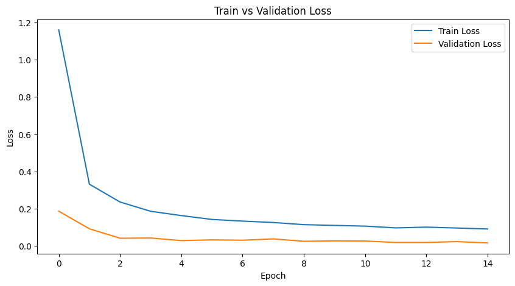

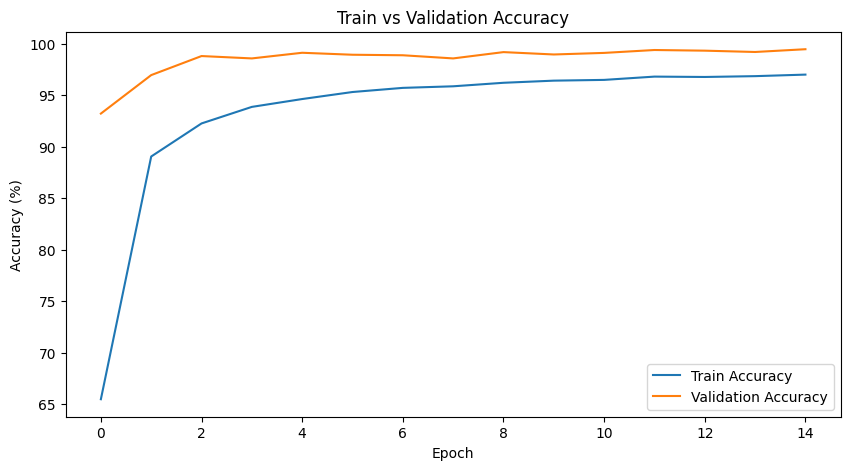

```python
# Loss curve plot
plt.figure(figsize=(10, 5))
plt.plot(train_losses, label='Train Loss')
plt.plot(val_losses, label='Validation Loss')
plt.xlabel('Epoch')
plt.ylabel('Loss')
plt.title('Train vs Validation Loss')
plt.legend()
plt.show()

# Accuracy curve plot
plt.figure(figsize=(10, 5))
plt.plot(train_accuracies, label='Train Accuracy')
plt.plot(val_accuracies, label='Validation Accuracy')
plt.xlabel('Epoch')
plt.ylabel('Accuracy (%)')
plt.title('Train vs Validation Accuracy')
plt.legend()
plt.show()
```

## Evaluation on Test dataset

In the following code snippet, I evaluate the model's performance with testing dataset. Getting average loss, and accuracy.

The model performs well with testing dataset as well, giving 96.38% accuracy, little less compared to Validation accuracy. Test loss = 0.1131, more than validation loss of 0.0162. This might be because I save the model that performs best according to validation set.

```python
# Test dataset evaluation

# resetting model
model = TrafficSignModel()
model.load_state_dict(torch.load('best_model.pth'))
model.to(device)

model.eval()

test_loss = 0.0
correct = 0
test_total = 0
criterion = nn.CrossEntropyLoss()

with torch.no_grad():
  for inputs, labels in test_loader:
    inputs, labels = inputs.to(device), labels.to(device)
    test_results = model(inputs)
    loss = criterion(test_results, labels)
    test_loss += loss.item() * inputs.size(0)

    _, predicts = torch.max(test_results, 1)
    correct += (predicts == labels).sum().item()
    test_total += labels.size(0)

# Get loss and accuracy
avg_test_loss = test_loss / test_total
test_accuracy = 100 * correct / test_total
print(f"Test Loss: {avg_test_loss:.4f}, Test Accuracy: {test_accuracy:.2f}%")
```

```
Test Loss: 0.1131, Test Accuracy: 96.38%
```

```
Testing sets
```

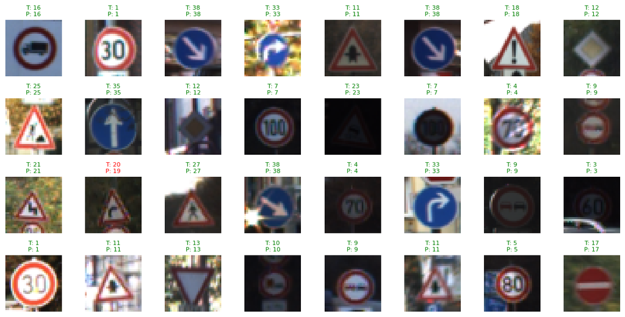

```
Training sets
```

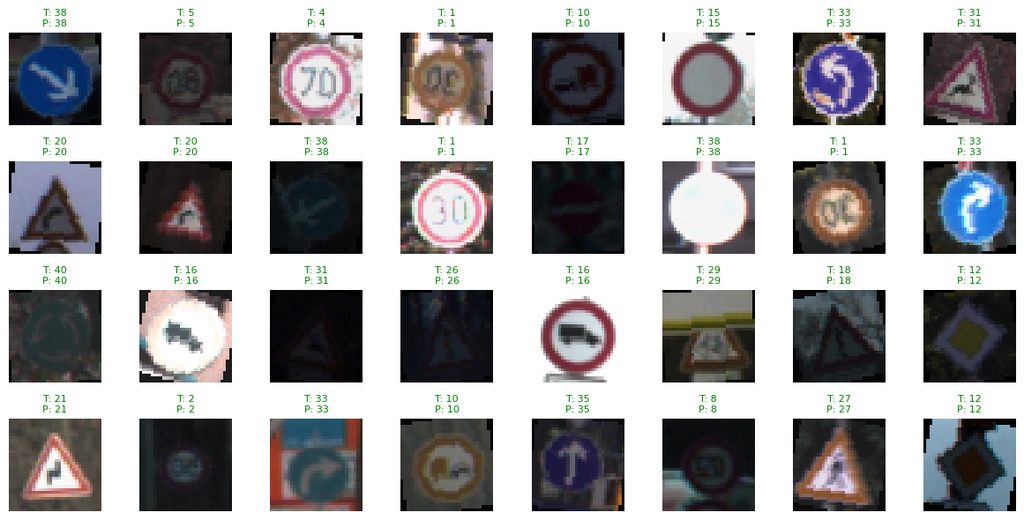

```python
'''
Here, I take a random batch of testing and training images, and use the model to predict and plot the output
denormalizing the images before plotting them, so that it would be clean in the output
Normalized image = (image - mean)/std
Therefore, denormalized image = (normalized image * std) + mean
'''
def deNormalize(normalized_image, mean, std):
  mean = torch.tensor(mean).view(3,1,1)
  std = torch.tensor(std).view(3,1,1)
  return (normalized_image * std) + mean

# setting the model for evaluation
model.eval()

# Getting from test dataset
images, labels = next(iter(test_loader))
images, labels = images.to(device), labels.to(device)

trainedImages, trainedLabels = next(iter(train_loader))
trainedImages, trainedLabels = trainedImages.to(device), trainedLabels.to(device)

with torch.no_grad():
    outputs_test = model(images)
    outputs_train = model(trainedImages)
    _, y_pred_test = torch.max(outputs_test, 1)
    _, y_pred_train = torch.max(outputs_train, 1)

mean = [0.485, 0.456, 0.406]
std = [0.229, 0.224, 0.225]

print("Testing sets\n")
# Plotting for testing sets
fig, ax = plt.subplots(4, 8, figsize=(12, 6))
ax = ax.flatten()

for i in range(32):
    image = images[i].cpu()
    image = deNormalize(image, mean, std)
    image = image.permute(1, 2, 0).numpy()
    ax[i].imshow(image)
    true_label = labels[i].item()
    pred_label = y_pred_test[i].item()
    color = 'green' if true_label == pred_label else 'red'
    ax[i].set_title(f"T: {true_label}\nP: {pred_label}", fontsize=8, color=color) # T: True label; P: Predicted label
    ax[i].set_axis_off()

plt.tight_layout()
plt.show()


print ("\nTraining sets\n")
# Plotting for training sets
fig, ax = plt.subplots(4, 8, figsize=(12, 6))
ax = ax.flatten()

for i in range(32):
    image = trainedImages[i].cpu()
    image = deNormalize(image, mean, std)
    image = image.permute(1, 2, 0).numpy()
    ax[i].imshow(image)
    true_label = trainedLabels[i].item()
    pred_label = y_pred_train[i].item()
    color = 'green' if true_label == pred_label else 'red'
    ax[i].set_title(f"T: {true_label}\nP: {pred_label}", fontsize=8, color=color) # T: True label; P: Predicted label
    ax[i].set_axis_off()

plt.tight_layout()
plt.show()
```

## Discussion

In the code section above, I retrieved a batch of training and testing set, denormalized the images so that they would be clean (back to its input form) for plotting.

From the plot that gets a batch of testing and training set, the model is able to correctly predict the label for all of the images but only one in the testing set(label marked red in color). The model performs well for training set batch.

These results are consistent with the test accuracy and train accuracy. The test accuracy(96.38%) was slightly lesser than training accuracy(97%) and validation accuracy(99.46%).

## Conclusion

I was able to get test accuracy of 96% for traffic sign recognition system using CNN model as I used different techniques for regularization, generalization, and building model inspired from VGG architecture.

Achieving high accuracy is crucial for self driving vehiles to make responsible and fast decisions. I plan to develop on this project over summer to expand its scope, explore other aspects of self driving vehicles, and improve my skills through practical experience.